# comparison

### TLDR. It doesn't really matter, difference is negligible. If you had started in 2013, Wednesday would have been ideal, but as of 2014 Friday appears to be the winner.

### The goal is to figure out which day of the week is the best day to set up a weekly bitcoin auto-buy.

#### I did the calculations for 24 hour highs, lows and the average of the two in order to show a worst-case to best-case scenario.

#### Some of the assumptions made.

- No transaction costs. (This is be the same as assuming constant transaction cost)
- Every purchase was 100 USD
- Coindesk has correct numbers
- Calculation are made from 2013-09-30 to 2020-12-22

```python
import pandas as pd
import datetime
import matplotlib
from helpers import seperate_into_weekdays, get_totals, get_average, plot_range, show_df, WEEKLY_BUY_USD
```

```python
# import data
historical_data = pd.read_csv('BTC_USD_2013-09-30_2020-12-22-CoinDesk.csv')

# clean and add relevant columns
historical_data['Date']= pd.to_datetime(historical_data['Date'])
historical_data['24h Mid (USD)'] = (historical_data['24h Low (USD)'] + historical_data['24h High (USD)']) / 2
historical_data['btc_at_highest_cost'] = WEEKLY_BUY_USD / historical_data['24h High (USD)']
historical_data['btc_at_lowest_cost'] = WEEKLY_BUY_USD / historical_data['24h Low (USD)']
historical_data['btc_at_average_cost'] = WEEKLY_BUY_USD / historical_data['24h Mid (USD)']
historical_data['week_day'] = historical_data['Date'].dt.day_name()
```

### Lets look at average BTC purchase for constant price in USD

|  | start | average_btc_at_lowest_cost | average_btc_at_average_cost | average_btc_at_highest_cost |
| --- | --- | --- | --- | --- |
| Monday | 2013-09-30 | 0.135853 | 0.132694 | 0.129822 |
| Tuesday | 2013-10-01 | 0.135807 | 0.132512 | 0.129563 |
| Wednesday | 2013-10-02 | 0.137195 | 0.133243 | 0.129844 |
| Thursday | 2013-10-03 | 0.136456 | 0.132947 | 0.129778 |
| Friday | 2013-10-04 | 0.136201 | 0.133122 | 0.130301 |
| Saturday | 2013-10-05 | 0.135205 | 0.132488 | 0.129975 |
| Sunday | 2013-10-06 | 0.135336 | 0.132304 | 0.129508 |

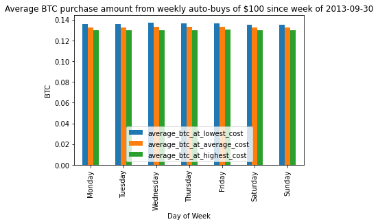

```python
day_charts = seperate_into_weekdays(historical_data)
day_of_week_vals = get_average(day_charts)
plot_range(day_of_week_vals, 'Average BTC purchase amount')
show_df(day_of_week_vals)
```

### Lets look at total BTC purchased for weekly autobuys of constant USD

|  | start | total_btc_at_lowest_cost | total_btc_at_average_cost | total_btc_at_highest_cost |
| --- | --- | --- | --- | --- |
| Monday | 2013-09-30 | 51.352589 | 50.158449 | 49.072891 |
| Tuesday | 2013-10-01 | 51.199204 | 49.957002 | 48.845227 |
| Wednesday | 2013-10-02 | 51.585286 | 50.099402 | 48.821320 |
| Thursday | 2013-10-03 | 51.307381 | 49.987941 | 48.796356 |
| Friday | 2013-10-04 | 50.939074 | 49.787460 | 48.732680 |
| Saturday | 2013-10-05 | 50.701932 | 49.682844 | 48.740703 |
| Sunday | 2013-10-06 | 50.750891 | 49.613885 | 48.565638 |

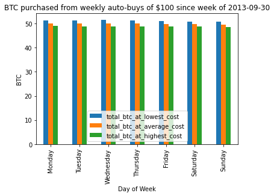

```python
day_charts = seperate_into_weekdays(historical_data)
day_of_week_vals = get_totals(day_charts)
plot_range(day_of_week_vals, 'BTC purchased')
show_df(day_of_week_vals)
```

#### Difference between days appears to be negligible

Since the purchases started in 2013 when BTC price was much lower compared to USD, this will give a much larger weight to the earlier days.

#### So lets explore if this holds for later

```python
# 2014 Jan 1st - today
day_charts = seperate_into_weekdays(historical_data, start_date=datetime.datetime(2014, 1, 1))
day_of_week_vals = get_average(day_charts)
show_df(day_of_week_vals)
```

|  | start | average_btc_at_lowest_cost | average_btc_at_average_cost | average_btc_at_highest_cost |
| --- | --- | --- | --- | --- |
| Monday | 2014-01-06 | 0.126294 | 0.123571 | 0.121055 |
| Tuesday | 2014-01-07 | 0.126592 | 0.123765 | 0.121176 |
| Wednesday | 2014-01-01 | 0.127098 | 0.124280 | 0.121704 |
| Thursday | 2014-01-02 | 0.127296 | 0.124396 | 0.121737 |
| Friday | 2014-01-03 | 0.127499 | 0.124890 | 0.122464 |
| Saturday | 2014-01-04 | 0.126781 | 0.124436 | 0.122226 |
| Sunday | 2014-01-05 | 0.126999 | 0.124407 | 0.121988 |

```python
# 2015 Jan 1st - today
day_charts = seperate_into_weekdays(historical_data, start_date=datetime.datetime(2015, 1, 1))
day_of_week_vals = get_average(day_charts)
show_df(day_of_week_vals)
```

|  | start | average_btc_at_lowest_cost | average_btc_at_average_cost | average_btc_at_highest_cost |
| --- | --- | --- | --- | --- |
| Monday | 2015-01-05 | 0.111888 | 0.109747 | 0.107746 |
| Tuesday | 2015-01-06 | 0.112507 | 0.110120 | 0.107927 |
| Wednesday | 2015-01-07 | 0.113204 | 0.110729 | 0.108478 |
| Thursday | 2015-01-01 | 0.113328 | 0.111074 | 0.108990 |
| Friday | 2015-01-02 | 0.113425 | 0.111303 | 0.109324 |
| Saturday | 2015-01-03 | 0.112825 | 0.110795 | 0.108882 |
| Sunday | 2015-01-04 | 0.112825 | 0.110669 | 0.108651 |

```python
# 2016 Jan 1st - today
day_charts = seperate_into_weekdays(historical_data, start_date=datetime.datetime(2016, 1, 1))
day_of_week_vals = get_average(day_charts)
show_df(day_of_week_vals)
```

|  | start | average_btc_at_lowest_cost | average_btc_at_average_cost | average_btc_at_highest_cost |
| --- | --- | --- | --- | --- |
| Monday | 2016-01-04 | 0.056599 | 0.055711 | 0.054876 |
| Tuesday | 2016-01-05 | 0.056866 | 0.055847 | 0.054899 |
| Wednesday | 2016-01-06 | 0.056994 | 0.055899 | 0.054885 |
| Thursday | 2016-01-07 | 0.056928 | 0.055757 | 0.054682 |
| Friday | 2016-01-01 | 0.057957 | 0.056757 | 0.055659 |
| Saturday | 2016-01-02 | 0.057374 | 0.056399 | 0.055481 |
| Sunday | 2016-01-03 | 0.057134 | 0.056200 | 0.055315 |

```python
# 2017 Jan 1st - today
day_charts = seperate_into_weekdays(historical_data, start_date=datetime.datetime(2017, 1, 1))
day_of_week_vals = get_average(day_charts)
show_df(day_of_week_vals)
```

|  | start | average_btc_at_lowest_cost | average_btc_at_average_cost | average_btc_at_highest_cost |
| --- | --- | --- | --- | --- |
| Monday | 2017-01-02 | 0.023452 | 0.022829 | 0.022255 |
| Tuesday | 2017-01-03 | 0.023282 | 0.022682 | 0.022126 |
| Wednesday | 2017-01-04 | 0.023380 | 0.022707 | 0.022091 |
| Thursday | 2017-01-05 | 0.023461 | 0.022669 | 0.021962 |
| Friday | 2017-01-06 | 0.023637 | 0.022846 | 0.022145 |
| Saturday | 2017-01-07 | 0.023274 | 0.022710 | 0.022189 |
| Sunday | 2017-01-01 | 0.023557 | 0.023009 | 0.022498 |

```python
# 2018 Jan 1st - today
day_charts = seperate_into_weekdays(historical_data, start_date=datetime.datetime(2018, 1, 1))
day_of_week_vals = get_average(day_charts)
show_df(day_of_week_vals)
```

|  | start | average_btc_at_lowest_cost | average_btc_at_average_cost | average_btc_at_highest_cost |
| --- | --- | --- | --- | --- |
| Monday | 2018-01-01 | 0.014049 | 0.013636 | 0.013259 |
| Tuesday | 2018-01-02 | 0.013997 | 0.013635 | 0.013303 |
| Wednesday | 2018-01-03 | 0.014014 | 0.013641 | 0.013297 |
| Thursday | 2018-01-04 | 0.014080 | 0.013676 | 0.013309 |
| Friday | 2018-01-05 | 0.014095 | 0.013708 | 0.013361 |
| Saturday | 2018-01-06 | 0.013855 | 0.013568 | 0.013299 |
| Sunday | 2018-01-07 | 0.013897 | 0.013574 | 0.013274 |

```python
# 2019 Jan 1st - today
day_charts = seperate_into_weekdays(historical_data, start_date=datetime.datetime(2019, 1, 1))
day_of_week_vals = get_average(day_charts)
show_df(day_of_week_vals)
```

|  | start | average_btc_at_lowest_cost | average_btc_at_average_cost | average_btc_at_highest_cost |
| --- | --- | --- | --- | --- |
| Monday | 2019-01-07 | 0.013456 | 0.013090 | 0.012752 |
| Tuesday | 2019-01-01 | 0.013443 | 0.013142 | 0.012862 |
| Wednesday | 2019-01-02 | 0.013462 | 0.013148 | 0.012854 |
| Thursday | 2019-01-03 | 0.013521 | 0.013152 | 0.012817 |
| Friday | 2019-01-04 | 0.013515 | 0.013175 | 0.012874 |
| Saturday | 2019-01-05 | 0.013311 | 0.013064 | 0.012830 |
| Sunday | 2019-01-06 | 0.013378 | 0.013076 | 0.012795 |

```python
# 2020 Jan 1st - today
day_charts = seperate_into_weekdays(historical_data, start_date=datetime.datetime(2020, 1, 1))
day_of_week_vals = get_average(day_charts)
show_df(day_of_week_vals)
```

|  | start | average_btc_at_lowest_cost | average_btc_at_average_cost | average_btc_at_highest_cost |
| --- | --- | --- | --- | --- |
| Monday | 2020-01-06 | 0.010556 | 0.010236 | 0.009944 |
| Tuesday | 2020-01-07 | 0.010350 | 0.010120 | 0.009903 |
| Wednesday | 2020-01-01 | 0.010496 | 0.010241 | 0.010002 |
| Thursday | 2020-01-02 | 0.010544 | 0.010188 | 0.009873 |
| Friday | 2020-01-03 | 0.010572 | 0.010250 | 0.009981 |
| Saturday | 2020-01-04 | 0.010399 | 0.010205 | 0.010022 |
| Sunday | 2020-01-05 | 0.010478 | 0.010227 | 0.009995 |

#### Apparently Friday is the best day to buy now.